# HW5:Classification

Author

Jacob Plax

Published

February 24, 2025

**Abstract:**

This is a technical blog post of **both** an HTML file *and* [.qmd file](https://raw.githubusercontent.com/JacobHack/DATA505HW/refs/heads/main/src/classify.qmd) hosted on GitHub pages.

# 0. Quarto Type-setting

- This document is rendered with Quarto, and configured to embed an images using the `embed-resources` option in the header.
- If you wish to use a similar header, here’s is the format specification for this document:

```
format:
  html:
    embed-resources: true
```

# 1. Setup

**Step Up Code:**

```r
sh <- suppressPackageStartupMessages
sh(library(tidyverse))
sh(library(caret))
sh(library(tidytext))
sh(library(SnowballC))
sh(library(pROC))
sh(library(glmnet))
data(stop_words)
sh(library(thematic))
wine <- readRDS(gzcon(url("https://github.com/cd-public/D505/raw/master/dat/pinot.rds")))
```

# 2. Logistic Concepts

**Why do we call it Logistic Regression even though we are using the technique for classification?**

It is called Logistic Regression because the alogirthm is fundamentally a regression model. We use logistic regression to predict the probability of a target variable belonging to a class. However, we do this by predicting a continuous value between 0 and 1 using a linear combination of features. We then assign it to a class based on a threshold value that we set which is commonly 0.5.

# 3. Modeling

## 3.1 Helper Functions and Setup

```r
desc_to_words <- function(df, omits) {
  df %>%
    unnest_tokens(word, description) %>%
    anti_join(stop_words) %>% # get rid of stop words
    filter(!(word %in% omits))
}

words <- desc_to_words(wine, c("wine","pinot","vineyard"))
# The second argument is our custom stopwards, as a vector
head(words)
```

```
  id province price points year     word
1  1   Oregon    65     87 2012  regular
2  1   Oregon    65     87 2012 bottling
3  1   Oregon    65     87 2012     2012
4  1   Oregon    65     87 2012    rough
5  1   Oregon    65     87 2012   tannic
6  1   Oregon    65     87 2012   rustic
```

### Explanation

- We define the `desc_to_words` function that tokenizes the `description` column into words, removes stop words, and filters out any words we specify
- We use this function on the `wine` dataset omitting the words `wine`, `pinot`, and `vineyard`
- We display the first few rows of the `words` dataframe we have created with our function

```r
words_to_stems <- function(df) {
  df %>%
    mutate(word = wordStem(word))
}

stems <- words_to_stems(words)
head(stems)
```

```
  id province price points year    word
1  1   Oregon    65     87 2012 regular
2  1   Oregon    65     87 2012   bottl
3  1   Oregon    65     87 2012    2012
4  1   Oregon    65     87 2012   rough
5  1   Oregon    65     87 2012  tannic
6  1   Oregon    65     87 2012  rustic
```

### Explanation

- We define the `words_to_stems` function that stems the words in a dataframe
- We call this on our `words` dataframe and print the first few rows

```r
filter_by_count <- function(df, j) {
  df %>%
    count(id, word) %>%
    group_by(id) %>% mutate(exists = (n>0)) %>% ungroup %>%
    group_by(word) %>%
    mutate(total = sum(n)) %>%
    filter(total > j)
}

fwords = filter_by_count(words, 1000)
head(fwords)
```

```
# A tibble: 6 × 5
# Groups:   word [5]
     id word          n exists total
  <int> <chr>     <int> <lgl>  <int>
1     2 drink         1 TRUE    1388
2     2 oak           2 TRUE    1198
3     3 aromas        1 TRUE    1459
4     3 bodied        1 TRUE    1016
5     3 oak           1 TRUE    1198
6     3 raspberry     1 TRUE    1394
```

```r
fstems = filter_by_count(stems, 1000)
head(fstems)
```

```
# A tibble: 6 × 5
# Groups:   word [6]
     id word      n exists total
  <int> <chr> <int> <lgl>  <int>
1     1 bottl     1 TRUE    1229
2     2 ag        1 TRUE    1101
3     2 berri     1 TRUE    1028
4     2 drink     1 TRUE    1573
5     2 oak       2 TRUE    1225
6     3 aroma     1 TRUE    1601
```

### Explanation

- We define the `filter_by_count` function that filters words based on their frequency
- We then call this function on the `words` dataframe keeping words that appear more than 1000 times and printing the first few rows
- We then call this function on the `stems` dataframe keeping stems that appear more than 1000 times and printing the first few rows

```r
pivoter <- function(words, df) {
  words %>%
    pivot_wider(id_cols = id, names_from = word, values_from = exists, values_fill = list(exists=0)) %>%
    right_join(select(df,id,province)) %>%
    drop_na() %>%
    select(-id)
}

head(pivoter(fwords, wine))
```

```
# A tibble: 6 × 23
  drink oak   aromas bodied raspberry spice finish fruit flavors tannins
  <lgl> <lgl> <lgl>  <lgl>  <lgl>     <lgl> <lgl>  <lgl> <lgl>   <lgl>
1 TRUE  TRUE  FALSE  FALSE  FALSE     FALSE FALSE  FALSE FALSE   FALSE
2 FALSE TRUE  TRUE   TRUE   TRUE      TRUE  FALSE  FALSE FALSE   FALSE
3 FALSE FALSE FALSE  FALSE  FALSE     FALSE TRUE   TRUE  FALSE   FALSE
4 FALSE FALSE FALSE  FALSE  FALSE     FALSE FALSE  FALSE TRUE    TRUE
5 TRUE  FALSE FALSE  FALSE  FALSE     FALSE FALSE  FALSE TRUE    FALSE
6 FALSE FALSE FALSE  FALSE  TRUE      FALSE FALSE  FALSE FALSE   FALSE
# ℹ 13 more variables: strawberry <lgl>, cranberry <lgl>, dark <lgl>,
#   palate <lgl>, acidity <lgl>, black <lgl>, cherry <lgl>, nose <lgl>,
#   ripe <lgl>, light <lgl>, red <lgl>, plum <lgl>, province <chr>
```

```r
head(pivoter(fstems, wine))
```

```
# A tibble: 6 × 30
  bottl ag    berri drink oak   aroma bodi  offer raspberri spice textur finish
  <lgl> <lgl> <lgl> <lgl> <lgl> <lgl> <lgl> <lgl> <lgl>     <lgl> <lgl>  <lgl>
1 TRUE  FALSE FALSE FALSE FALSE FALSE FALSE FALSE FALSE     FALSE FALSE  FALSE
2 FALSE TRUE  TRUE  TRUE  TRUE  FALSE FALSE FALSE FALSE     FALSE FALSE  FALSE
3 FALSE FALSE FALSE FALSE TRUE  TRUE  TRUE  TRUE  TRUE      TRUE  TRUE   FALSE
4 FALSE FALSE FALSE FALSE FALSE FALSE FALSE FALSE FALSE     FALSE FALSE  TRUE
5 FALSE FALSE TRUE  FALSE FALSE FALSE FALSE FALSE FALSE     FALSE FALSE  FALSE
6 FALSE FALSE FALSE TRUE  FALSE FALSE FALSE FALSE FALSE     FALSE FALSE  FALSE
# ℹ 18 more variables: flavor <lgl>, fruit <lgl>, ripe <lgl>, tannin <lgl>,
#   strawberri <lgl>, cranberri <lgl>, dark <lgl>, palat <lgl>, acid <lgl>,
#   black <lgl>, cherri <lgl>, nose <lgl>, light <lgl>, red <lgl>, rich <lgl>,
#   plum <lgl>, structur <lgl>, province <chr>
```

### Explanation

- We define the function `pivoter` that pivots the dataframe to a wider format more suitable for modeling by making sure each id has features where each id is a wine
- We call this function on the `fwords` dataframe and display the first few rows
- We call this function on the `fstems` dataframe and display the first few rows

```r
wine_words <- function(df, j, stem) {

  words <- desc_to_words(df, c("wine","pinot","vineyard"))

  if (stem) {
    words <- words_to_stems(words)
  }

  words <- filter_by_count(words, j)

  pivoter(words, df)
}

wino <- wine_words(wine, 500, F)
wino <- wino %>%
  mutate(marlborough = factor(province=="Marlborough")) %>%
  select(-province)

wino %>%
  head(10) %>%
  select(1:5, marlborough)
```

```
# A tibble: 10 × 6
   bottling earthy berry chocolate drink marlborough
   <lgl>    <lgl>  <lgl> <lgl>     <lgl> <fct>
 1 TRUE     TRUE   FALSE FALSE     FALSE FALSE
 2 FALSE    FALSE  TRUE  TRUE      TRUE  FALSE
 3 FALSE    FALSE  FALSE FALSE     FALSE FALSE
 4 FALSE    FALSE  FALSE FALSE     FALSE FALSE
 5 FALSE    TRUE   TRUE  FALSE     FALSE FALSE
 6 FALSE    FALSE  FALSE FALSE     TRUE  FALSE
 7 TRUE     FALSE  FALSE FALSE     FALSE FALSE
 8 FALSE    FALSE  FALSE FALSE     FALSE FALSE
 9 FALSE    FALSE  FALSE FALSE     FALSE FALSE
10 FALSE    FALSE  FALSE FALSE     FALSE FALSE
```

### Explanation

- We define the `wine_words` function that combines our previous functions to create features from the dataframe
- We apply this function to the `wine` dataframe to keep words that appear more than 500 times and we do not stem the words
- We create a new column in the `wino` dataframe called `marlborough` that indicates whether or not the province is Marlborough and then we remove the `province` column
- We then display the first 10 rows of the `wino` dataframe only looking at the first 5 columns and the `marlborough` column

We train a logistic regression algorithm to classify a whether a wine comes from Marlborough using:

```r
set.seed(505)
wine_index <- createDataPartition(wino$marlborough, p = 0.80, list = FALSE)
train <- wino[ wine_index, ]
test <- wino[-wine_index, ]

control = trainControl(method = "cv", number = 5)
get_fit <- function(df) {
  train(marlborough ~ .,
        data = df,
        trControl = control,
        method = "glm",
        family = "binomial",
        maxit = 5) # speed it up - default 100
}
fit <- get_fit(train)
fit
```

```
Generalized Linear Model

6695 samples
  54 predictor
   2 classes: 'FALSE', 'TRUE'

No pre-processing
Resampling: Cross-Validated (5 fold)
Summary of sample sizes: 5355, 5356, 5357, 5356, 5356
Resampling results:

  Accuracy   Kappa
  0.9804325  0.5281636
```

### Explanation

- We create an 80-20 train-test split based on the `marlborough` column
- We create our training and test sets
- We define a function `get_fit` to train a logistic regression model with 5-fold cross-validation using a `glm`
- We then train and print the model

# 4. Binary vs Other Classification

**What is the difference between determining some form of classification through logistic regression versus methods like $K$-NN and Naive Bayes which performed classifications.**

## Logistic Regression:

- Type: Parametric
- Model: Linear model that predicts the probability of a binary outcome using a logistic function.
- Assumptions: Assumes a linear relationship between the features and the log-odds of the outcome.
- Interpretability: Coefficients can be interpreted as the change in log-odds for a unit change in the predictor.
- Training: Finds the best-fitting parameters using maximum likelihood estimation.
- Pros: Simple, interpretable, works well with linearly separable data.
- Cons: May not perform well with non-linear relationships.

## K-Nearest Neighbors (K-NN):

- Type: Non-parametric
- Model: Classifies a data point based on the majority class among its k-nearest neighbors.
- Assumptions: No explicit assumptions about the data distribution.
- Interpretability: Less interpretable as it relies on the distance metric and the choice of k.
- Training: No explicit training phase; classification is done during prediction.
- Pros: Simple, intuitive, works well with non-linear boundaries.
- Cons: Computationally expensive for large datasets, sensitive to the choice of k and the distance metric.

## Naive Bayes:

- Type: Parametric
- Model: Probabilistic model based on Bayes’ theorem with the assumption of feature independence.
- Assumptions: Assumes that features are conditionally independent given the class label.
- Interpretability: Probabilities can be interpreted directly, and the model is easy to understand.
- Training: Estimates the probability distributions of the features given the class labels.
- Pros: Fast, works well with high-dimensional data, robust to irrelevant features.
- Cons: Assumption of feature independence may not hold in practice, leading to suboptimal performance

## Summary

**Logistic Regression**: is a linear model that predicts the probability of a binary outcome using a logistic function. It is simple and interpretable but may not perform well with non-linear relationships.

**K-NN**: is a non-parametric method that classifies a data point based on the majority class among its k-nearest neighbors. It is intuitive and works well with non-linear boundaries but can be computationally expensive for large datasets.

**Naive Bayes**: is a probabilistic model based on Bayes’ theorem with the assumption of feature independence. It is fast and works well with high-dimensional data but may not perform well if the independence assumption is violated.

# 5. ROC Curves

We can display an ROC for the model to explain your model’s quality.

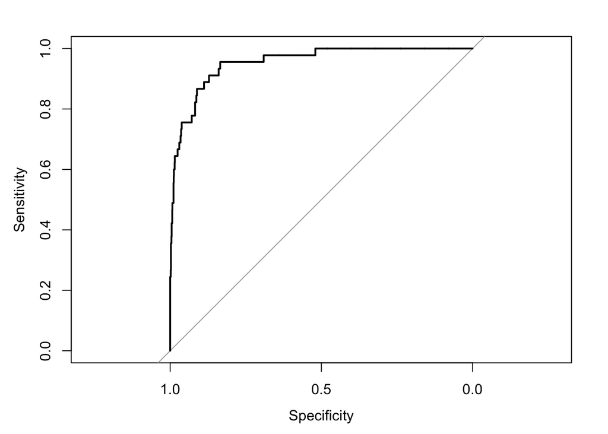

```r
prob <- predict(fit, newdata = test, type = "prob")[,2]
myRoc <- roc(test$marlborough, prob)
plot(myRoc)
```

```r
auc(myRoc)
```

```
Area under the curve: 0.9541
```

### Explanation of Code

- This code evaluates our model using a ROC(Reciever Operating Characteristic) curve and the AUC(Area Under the Curve) metric.
- We generate the predicted probabilities for the test set and find the probability of the positive class which in this case is whether or not wine comes from Marlborough
- We then compute the ROC using the actual labels and our predicted probabilities and plot it
- Finally we compute the AUC fo the ROC curve which sumarizes the performance of the model on a 0-1 scale. 0.5 is equivalent to random guessing and values closer to 1 indicate a better performing model.
- Our AUC is 0.9541 which indicates our model is pretty good at predicting whether or not a wine comes from Marlborough

### Explanation of Model Quality

**ROC Curve**: The ROC curve provides a visual assessment of the model’s ability to distinguish between the positive and negative classes across different thresholds. A curve that is closer to the top left corner indicates a better-performing model.

**AUC**: The AUC quantifies the overall ability of the model to discriminate between the positive and negative classes. A higher AUC value indicates better model performance.